```python
#Saba Syed
#PHYS191-03
#LAB 2
#09/14/2020
```

# Velocity and acceleration - Measuring acceleration due to gravity

## Objective:

#### The goal of this experiment is to study the motion of an object sliding down an incline, and how the effect of changing height (and angle) of an incline influences the velocity and acceleration of the object rolling down. The velocity and acceleration of a cart will be calculated, graphed, and analyzed to find the value of g.

## Introduction:

#### All objects experience acceleration due to gravity during free fall motion (acceleration due gravity is denoted as $g$). We know this acceleration is about $9.8~m/s^2$ at sea level. Rather than dropping objects off buildings or jumping out of airplanes, we will time an object (a cart) as it rolls freely down an inclined plane (ramp). By timing the fall (or roll down) of the cart and measuring the distance rolled, we can calculate the displacement from the initial position, the average velocity, and the final velocity of the cart and determine its acceleration due to gravity down an incline at different heights. Then we can graph the data, and use the slope of the line to calculate $g$.

## Materials:

#### 1. An incline (1.2 meter marked track)

#### 2. Wooden blocks or 4 textbooks

#### 3. Rolling cart

#### 4. Inclination angle measuring device (you can use physics toolbox app on android and iOS).

#### The setup is shown below

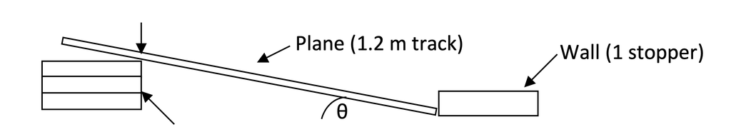

```python
from IPython.display import Image
Image('fig1.png', width=1000, height=1000)
```

## Theory:

#### Objects under acceleration experiences an increase in their velocity with time. If the acceleration is a constant $a$, and if the object starts from a position of rest i.e., $v_{\rm initial} = 0$, then the final velocity after time $t$ is given by $v_{\rm final} = at$. Thus It is possible to calculate the acceleration experienced by an object calculating. Since the average velocity is just the distance $s$, divided by time $t$, and since $s = \frac{1}{2}at^2$, we can write $v_{\rm avg} = \frac{1}{2}\frac{at^2}{t} = \frac{1}{2}at = v_{\rm final}/2$. Thus we can calculate the acceleration of the systems using the average velocity as $a = 2v_{\rm avg}/t$.

#### We will use this concept of average velocity to calculate the acceleration of a cart rolling down the inclined plank. The expected acceleration of the cart is given by $a = g\sin\theta$. If we calculate the angle $\theta$ and the acceleration using the average velocity above, we can then calculate the acceleration due to gravity:

### $g = 2\frac{v_{\rm avg}}{t\sin\theta}$

## Procedure:

#### 1. On a clear table top set up an inclined plane as in the diagram above using the $1.2 m$ long track or a wooden board. The track already has a metric scale built in. If you are using a wooden board tap a carpenter ruler with the zero point at the top of the board. Raise the $0$m end at a height of $0.05$ to $0.1 m$ (or $5$ to $10$cm around $3$ inches). (use block of wood, or 1 Physics textbook for this height). lay your phone using PhysicsToolbox to find the incline angle. you can also use the right triangle formula below to find the angle of the incline

#### $\sin\theta = \frac{{\rm height~of~the~upper~end}}{{\rm length~of~the~board}}$

#### 2. The zero of the scale should be at the upper end/ Hold the cart at the upper end of the board as far away from the lower end possible. Note the reading on the scale where front of the cart is placed. This is your starting value of position $x_0$.

#### 3. Now release the cart carefully, without giving any forward, backward or sidways push so that the initial velocity is zero. Right at the moment of releasing the cart start your stopwatch. If you are using a phone then it is very important that you ask someone else to measure time.

#### 4. Let the stopwatch run as long as the cart is sliding. The moment the cart hits the wall at the other end, stop the stopwatch.

#### 5. Note down the time, and then repeat it for four more times.

#### 6. Calculate the average time taken for this point of $x_0$.

#### 7. Now change the position of the $x_0$ to a new point $\sim 10$ cm away from the first point.

#### 8. Repeat steps 3, 4, 5, and 6.

#### 9. Continue repeating this for a total of $10$ different value of $x_0$.

#### 10. Then change angle of the incline to a higher value by raising the upper end by using another block/book, and repeat the full experiment for this new angle.

#### 11. Repeat this again for a third angle.

```python
import numpy as np
import pylab as pl
import pandas as pd
```

### Measurement of the angle of the plank

#### The angles are measured using Physics Toolbox app on android. Each measurement is repeated 10 times, and then the average is used.

```python
# Angle measurement using one blocks ######################################

### Put your numbers here (ten numbers) ###
angles = [1.90, 1.96, 1.98, 1.86, 1.85, 1.70, 1.60, 1.56, 1.46, 1.36]
#############################


measured_angles = np.array(angles)
mean_angle_1 = np.mean(measured_angles)
mean_angle_1_radians = np.deg2rad(mean_angle_1)
print("Mean angle in degrees = {}".format(mean_angle_1))
print("Mean angle in radians = {}".format(mean_angle_1_radians))
```

```
Mean angle in degrees = 1.723
Mean angle in radians = 0.0300720230118623
```

```python
### Put real values, I have put -1 as placeholders. Erase the -1's and put measured values. Mind the commas!

# Angle measurement using two blocks (ten numbers) #
######################################

### Put your numbers here ###
angles = [ 1.92, 1.93, 1.99, 1.86, 1.78, 1.79, 1.64, 1.60, 1.42, 1.39]
#############################


measured_angles = np.array(angles)
mean_angle_2 = np.mean(measured_angles)
mean_angle_2_radians = np.deg2rad(mean_angle_1)
print("Mean angle in degrees = {}".format(mean_angle_2))
print("Mean angle in radians = {}".format(mean_angle_2_radians))
```

```
Mean angle in degrees = 1.732
Mean angle in radians = 0.0300720230118623
```

```python
### Put real values, I have put -1 as placeholders. Erase the -1's and put measured values. Mind the commas!

# Angle measurement using three blocks #
########################################

### Put your numbers here  (ten numbers) ###
angles = [1.95, 1.99, 1.99, 1.89, 1.89, 1.72, 1.62, 1.58, 1.49, 1.39]
#############################


measured_angles = np.array(angles)
mean_angle_3 = np.mean(measured_angles)
mean_angle_3_radians = np.deg2rad(mean_angle_3)
print("Mean angle in degrees = {}".format(mean_angle_3))
print("Mean angle in radians = {}".format(np.deg2rad(mean_angle_3)))
```

```
Mean angle in degrees = 1.7510000000000001
Mean angle in radians = 0.03056071520242071
```

## Analysis:

### Here the analysis is shown for only one inclination angle. You will have to repeat it for two more cases

```python
## Read the data file and unpack all the columns to variables to store them ##

### Give the name of your data file here ###
fname = 'slide_trials_second_angle.txt'
############################################



## Don't change anything below unless you know what you are doing ##
trials, t_105, t_100, t_90, t_80, t_70, t_60, t_50, t_40, t_30, t_20 = np.loadtxt(fname, unpack=True)

## Display table ##
pd.DataFrame(np.vstack((trials, t_20, t_30, t_40, t_50, t_60, t_70, t_80, t_90, t_100, t_105)).T,
             columns=['trial #', 't(20 cm)', 't(30 cm)', 't(40 cm)', 't(50 cm)', 't(60 cm)',
                      't(70 cm)', 't(80 cm)', 't(90 cm)', 't(100 cm)', 't(105 cm)'])
```

|  | trial # | t(20 cm) | t(30 cm) | t(40 cm) | t(50 cm) | t(60 cm) | t(70 cm) | t(80 cm) | t(90 cm) | t(100 cm) | t(105 cm) |
| --- | --- | --- | --- | --- | --- | --- | --- | --- | --- | --- | --- |
| 0 | 1.0 | 1.37 | 1.47 | 1.59 | 1.64 | 1.74 | 1.86 | 1.88 | 1.98 | 1.98 | 1.93 |
| 1 | 2.0 | 1.36 | 1.46 | 1.64 | 1.65 | 1.75 | 1.82 | 1.87 | 1.88 | 1.97 | 1.95 |
| 2 | 3.0 | 1.44 | 1.42 | 1.58 | 1.59 | 1.82 | 1.81 | 1.84 | 1.91 | 1.94 | 1.99 |
| 3 | 4.0 | 1.35 | 1.45 | 1.56 | 1.62 | 1.72 | 1.82 | 1.81 | 1.96 | 1.96 | 1.96 |
| 4 | 5.0 | 1.39 | 1.40 | 1.61 | 1.66 | 1.76 | 1.75 | 1.89 | 1.97 | 1.99 | 1.97 |

```python
## Don't change anything here unless you know what you are doing ##
## Calculate the mean of the times taken ##
t_20_mean = np.mean(t_20)  # Average time taken by cart to slide by 20 cm
t_30_mean = np.mean(t_30)  # Average time taken by cart to slide by 30 cm
t_40_mean = np.mean(t_40)  # Average time taken by cart to slide by 40 cm
t_50_mean = np.mean(t_50)  # Average time taken by cart to slide by 50 cm

t_60_mean = np.mean(t_60)  # Average time taken by cart to slide by 60 cm
t_70_mean = np.mean(t_70)  # Average time taken by cart to slide by 70 cm
t_80_mean = np.mean(t_80)  # Average time taken by cart to slide by 80 cm
t_90_mean = np.mean(t_90)  # Average time taken by cart to slide by 90 cm

t_100_mean = np.mean(t_100)  # Average time taken by cart to slide by 100 cm
t_105_mean = np.mean(t_105)  # Average time taken by cart to slide by 105 cm
```

```python
## Don't change anything here unless you know what you are doing ##
## Convert them to arrays to make the plots ##
x1 = np.array([20, 30, 40, 50, 60, 70, 80, 90, 100, 105])/100 # Dividing by 100 to convert to meters
t1 = np.array([t_20_mean, t_30_mean, t_40_mean, t_50_mean, t_60_mean,
              t_70_mean, t_80_mean, t_90_mean, t_100_mean, t_105_mean])
```

### Calculating the average velocity using $v_{\rm avg} = \frac{x}{t}$. And then calculating final velocity at the end of time $t$ using $v(t) = v_{\rm final} = 2\times v_{\rm avg}$

```python
## Don't change anything here unless you know what you are doing ##
v1_avg = x1/t1  # Calculating the value of average velocity
v1 = 2*v1_avg  # Calcuting the velocity at the end of the time t
print ("Values of the final velocities are {}".format(v1))
```

```
Values of the final velocities are [0.2894356  0.41666667 0.50125313 0.6127451  0.68259386 0.77262693
 0.86114101 0.92783505 1.01626016 1.07142857]
```

```python
## Don't change anything here unless you know what you are doing ##
v1_expect = 0.175*t1  # Theoretically expected value of the velocity
```

### Analyze the second inclination angle. Please note that this file named `slide_trials_second_angle.txt` will be a dummy, with just a copy of the `slide_trials_first_angle.txt` file. You will need to fill in this file from your experiment.

```python
## Read the data file and unpack all the columns to variables to store them ##
## If you are doing different values of slide-lengths that is not a problem in this cell
## However, make sure you do 10 sets of lengths like I did, and in columns start with the
## largest length on the left most column to the smallest sliding length on the right.

### Give the name of your data file here ###
fname = 'slide_trials_second_angle.txt'
############################################



trials, t_105, t_100, t_90, t_80, t_70, t_60, t_50, t_40, t_30, t_20 = np.loadtxt(fname, unpack=True)

## Calculate the mean of the times taken ##
t_20_mean = np.mean(t_20)
t_30_mean = np.mean(t_30)
t_40_mean = np.mean(t_40)
t_50_mean = np.mean(t_50)
t_60_mean = np.mean(t_60)
t_70_mean = np.mean(t_70)
t_80_mean = np.mean(t_80)
t_90_mean = np.mean(t_90)
t_100_mean = np.mean(t_100)
t_105_mean = np.mean(t_105)

## Change this if you lengths are different ##
x2 = np.array([20, 30, 40, 50, 60, 70, 80, 90, 100, 105])/100

t2 = np.array([t_20_mean, t_30_mean, t_40_mean, t_50_mean, t_60_mean,
              t_70_mean, t_80_mean, t_90_mean, t_100_mean, t_105_mean])

v_avg_2 = x2/t2
v2 = 2*v_avg_2
v2_expect = 0.175*t2  # USE YOUR VALUE OF g.sin(theta) = 9.8*sin(theta2)FOR THIS ANGLE.
```

```python
### Copy the entire cell above in this cell, and do the same analysis for the third angle
### Talk to me if you have difficulty with this
## Read the data file and unpack all the columns to variables to store them ##
## If you are doing different values of slide-lengths that is not a problem in this cell
## However, make sure you do 10 sets of lengths like I did, and in columns start with the
## largest length on the left most column to the smallest sliding length on the right.

### Give the name of your data file here ###
fname = 'slide_trials_third_angle.txt'
############################################



trials, t_105, t_100, t_90, t_80, t_70, t_60, t_50, t_40, t_30, t_20 = np.loadtxt(fname, unpack=True)

## Calculate the mean of the times taken ##
t_20_mean = np.mean(t_20)
t_30_mean = np.mean(t_30)
t_40_mean = np.mean(t_40)
t_50_mean = np.mean(t_50)
t_60_mean = np.mean(t_60)
t_70_mean = np.mean(t_70)
t_80_mean = np.mean(t_80)
t_90_mean = np.mean(t_90)
t_100_mean = np.mean(t_100)
t_105_mean = np.mean(t_105)

## Change this if you lengths are different ##
x3 = np.array([20, 30, 40, 50, 60, 70, 80, 90, 100, 105])/100

t3 = np.array([t_20_mean, t_30_mean, t_40_mean, t_50_mean, t_60_mean,
              t_70_mean, t_80_mean, t_90_mean, t_100_mean, t_105_mean])

v_avg_3 = x2/t3
v3 = 2*v_avg_3
v3_expect = 0.175*t3  # USE YOUR VALUE OF g.sin(theta) = 9.8*sin(theta2)FOR THIS ANGLE.
```

## Graphs

### We will now make the Distance vs Time graph for this observation

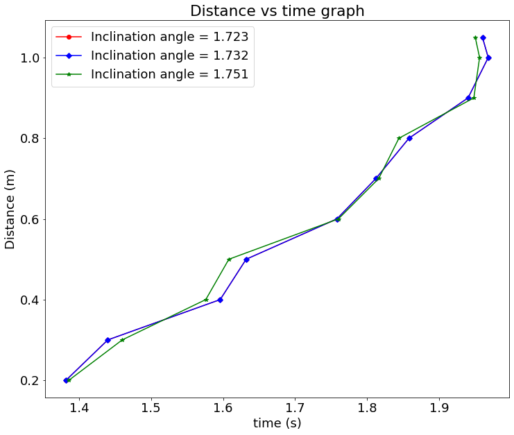

```python
pl.rcParams.update({'font.size': 18}) # Sets fontsize to 18
pl.figure(figsize=(12,10)) # Sets figure size to be 12 x 10

# Plots t along x axis, and x along y-axis. Uses red (r) circular (o) markers joined by line
pl.plot(t1, x1, 'ro-', label="Inclination angle = {}".format(np.round(mean_angle_1, 3)))

# Second experiment
pl.plot(t2, x2, 'bD-', label="Inclination angle = {}".format(np.round(mean_angle_2, 3)))

# Third experiment
pl.plot(t3, x3, 'g*-', label="Inclination angle = {}".format(np.round(mean_angle_3, 3)))

pl.legend() # Makes the legend
pl.xlabel('time (s)') # label the y-axis as time
pl.ylabel('Distance (m)') # label the x-axis as Distance
pl.title('Distance vs time graph')
```

### We will now make Velocity vs Time graph for this observation

[figure not shown]

```python
pl.rcParams.update({'font.size': 18}) # Sets fontsize to 18
pl.figure(figsize=(12,10)) # Sets figure size to be 12 x 10

pl.plot(t1, v1, 'ro-', label='Observed - inclination angle = {}'.format(np.round(mean_angle_1, 3)))
pl.plot(t1, v1_expect, 'r--', label='Expected') # Plotting the expected velocity vs time graph

pl.plot(t2, v2, 'bD-', label='Observed - inclination angle = {}'.format(np.round(mean_angle_1, 3)))
pl.plot(t2, v2_expect, 'b--', label='Expected')

pl.plot(t3, v3, 'g*-', label='Observed - inclination angle = {}'.format(np.round(mean_angle_1, 3)))
pl.plot(t3, v3_expect, 'g--', label='Expected')

pl.xlabel('time (t)')
pl.ylabel('Velocity')
pl.legend()  #  Putting the legend on the figure
pl.title('Velocity vs time graph')
```

## Calculation of acceleration due to gravity

```python
## g is computed by dividing the acceleration by the sine of the angle of inclination ##
## But acceleration is simply the ratio of the velocity w.r.t the time.

g1 = (v1/t1)/np.sin(mean_angle_1_radians)

## g average
g1_avg = np.mean(g1)
print("Average value of g from the first inclination angle = {}".format(g1_avg))

##################################################################################

g2 = (v2/t2)/np.sin(mean_angle_2_radians)

## g average
g2_avg = np.mean(g2)
print("Average value of g from the second inclination angle = {}".format(g2_avg))

##################################################################################
# Activate the lines below by removing the hashtags from the begining of the lines

g3 = (v3/t3)/np.sin(mean_angle_3_radians)
g3_avg = np.mean(g2)
print("Average value of g from the third inclination angle = {}".format(g3_avg))
```

```
Average value of g from the first inclination angle = 13.329229628047035
Average value of g from the second inclination angle = 13.329229628047035
Average value of g from the third inclination angle = 13.329229628047035
```

## Error Anaysis

### Fractional percentage error:

#### The value of fractional percetage error can be computed if the true value of the $g$.

```python
frac_perc_error1 = (g1_avg - 9.8)*100/9.8
frac_perc_error1 = np.round(frac_perc_error1)
print("The fractional percentage error in first inclination angle = {}".format(frac_perc_error1))
```

```
The fractional percentage error in first inclination angle = 36.0
```

```python
frac_perc_error2 = (g2_avg - 9.8)*100/9.8
frac_perc_error2 = np.round(frac_perc_error2)
print("The fractional percentage error in second inclination angle = {}".format(frac_perc_error2))
```

```
The fractional percentage error in second inclination angle = 36.0
```

```python
## Use the same calculation above to calculate the fractional error for the third angle.
frac_perc_error3 = (g3_avg - 9.8)*100/9.8
frac_perc_error3 = np.round(frac_perc_error3)
print("The fractional percentage error in third inclination angle = {}".format(frac_perc_error3))
```

```
The fractional percentage error in third inclination angle = 36.0
```

### Root mean square error

#### When the true value is known one can also calculate the root-mean-square error. This is done by first computing the difference of the value from the true value and squaring it. Then we sum all these squares and take the mean. And finally we take the square root of the result.

### $\sqrt{\frac{1}{N}\sum(g - 9.8)^2}$

```python
rms1 = np.sqrt(np.mean(g1 - 9.8)**2)
rms1 = np.round(rms1, 2)
rms2 = np.sqrt(np.mean(g2 - 9.8)**2)
rms2 = np.round(rms2, 2)
rms3 = np.sqrt(np.mean(g3 - 9.8)**2)
rms3 = np.round(rms3, 2)
print("The value of the root-mean-square error for the first inclination angle = {}".format(rms1))
print("The value of the root-mean-square error for the second inclination angle = {}".format(rms2))
print("The value of the root-mean-square error for the third inclination angle = {}".format(rms3))
```

```
The value of the root-mean-square error for the first inclination angle = 3.53
The value of the root-mean-square error for the second inclination angle = 3.53
The value of the root-mean-square error for the third inclination angle = 3.39
```

#### Finally, we will calculate the statistical uncertainty in our measurement, that doesn't require us to know the true value of $g$. This is done by calculating the standard deviation. The standard deviation of the value of $g$ is given by:

### $\sigma (g)= \sqrt{\bar{g^2} - (\bar{g})^2}$

#### Where, $\bar{g}$ is the average value of $g$ and $\bar{g^2}$ is the average value of $g^2$.

```python
g1_avg_square = g1_avg**2
## g^2 average
g1_square_avg = np.mean(g1**2)

## Now we calculate the standard deviation
sigma_g1 = np.sqrt(g1_square_avg - g1_avg_square)
sigma_g1 = np.round(sigma_g1, 2)  #  Rounding off to 2 decimal places
print("Standard deviation of the measurement is = {}".format(sigma_g1))
```

```
Standard deviation of the measurement is = 3.37
```

```python
## Please repeate the above calculation for the second and the third angles.
## Insert cells below and copy the above lines there and change the variables
## to the correct ones for the other angles.
## if you have difficulty please let me know

g3_avg_square = g3_avg**2
## g^2 average
g3_square_avg = np.mean(g3**2)

## Now we calculate the standard deviation
sigma_g3 = np.sqrt(g1_square_avg - g3_avg_square)
sigma_g3 = np.round(sigma_g1, 2)  #  Rounding off to 2 decimal places
print("Standard deviation of the measurement is = {}".format(sigma_g3))
```

```
Standard deviation of the measurement is = 3.37
```

## PLEASE WRITE DISCUSSIONS AND CONCLUSION

#### Talk about how you did this experiment. This is especially important since you are doing it at home so I will be interested to know how you have improvised in this experiment. Talk abut what difficulty you faced, and how you managed it. How you got help from someone. The most challenging aspect of this lab. If you took some photo of you doing this experiment, don't forget to attach it here. Use the same trick I used above to attache the photo of the illustration at the top. Here is the syntax: `Image('fig1.png', width=1000, height=1000)`. Change the `width` and `height` values to make it fit in the notebook.

```python
# The way I did the experiement is I set up a plank on 3 text books and rolled three different types of toy cars on the plank trying to measure the velocity. The only difficult that I faced was trying to capture the acceleration with my phone as closely as possible without messing up the experiment and also the calculation from my phone. The way I managed is i tried to get as closely to the real number as possible. My phone didn't not calculate into three decimals only into two. The professor going over the way to use the jupyter hub was really informative now I know where I made mistakes in the experiments. The most challenging was making the program work as it is supposed to work so my calculations would not be wrong. The error percent is a little high but that is because I did the experiment at home but it is not in the hundreds so it is fine. Also, I did not know that jupyter hub was not autosave and my pictures got deleted.
```